# IscA

Fold-switch pair **1x0gD_1x0gA** — **1x0gD** vs **1x0gA**

Thermosynechococcus vestitus BP-1

## Figure 1: Phylogenetic tree with per-cluster fold-preference heatmap.

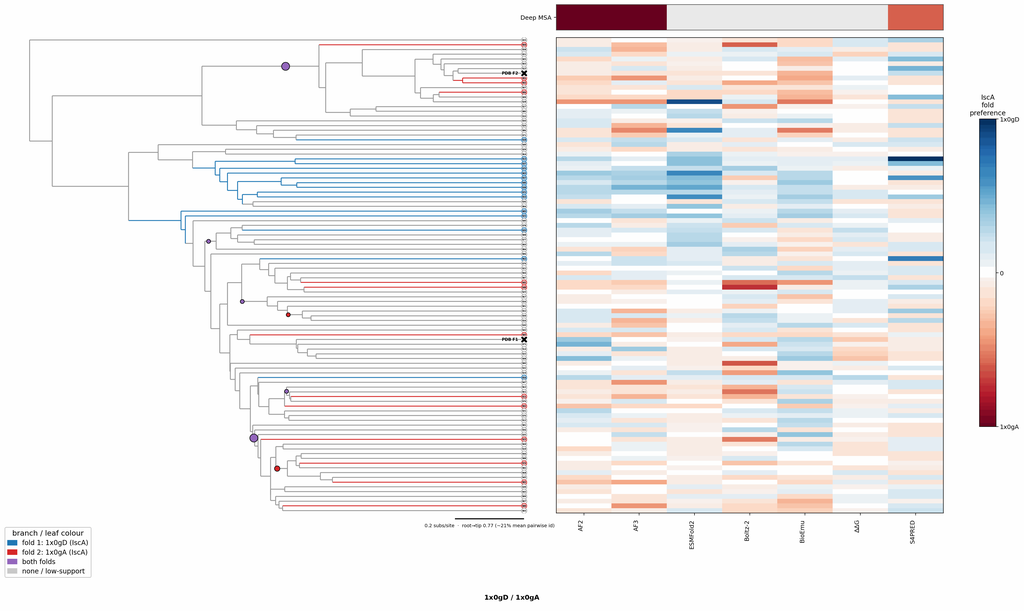

## Figure 2: Aligned overlay (both folds superposed)

The single fold-switching chain of each fold superposed by TM-align; waters hidden, any ligand shown as green sticks. Grey = structurally conserved core, colour = divergent (fold-switching) region.

1x0gD (IscA)1x0gA (IscA)Ligand FES (bound to 1x0gD), Ligand FES (bound to 1x0gA)

TM-score: 0.553 · Trigger class: equilibrium_or_unknown

Aligned overlay

Loading...

## Figure 3: The two folds, side by side

Each fold is coloured by per-residue Cα deviation between the two superposed structures: grey ≈ conserved core, full colour = structurally divergent (fold-switching) region.

1x0gD (IscA)

1x0gA (IscA)

0 Å5≥10 Å

1x0gD (IscA)

Loading...

1x0gA (IscA)

Loading...

## Figure 4: Best-cluster predicted contact maps over the two true folds.

Predicted contact maps (MSA-Transformer) for the clusters best matching each fold, over the true contacts of fold 1 (upper triangle) and fold 2 (lower). Divergent contacts between clusters are the contact-level signature of fold-switching.

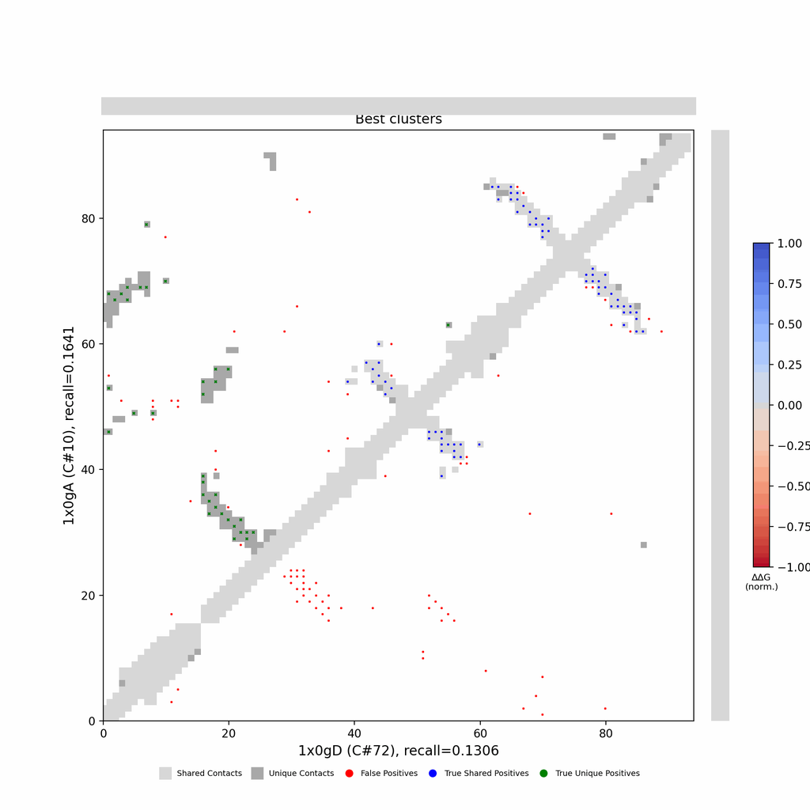

## Figure 5: Per-residue ΔΔG fold-preference contribution

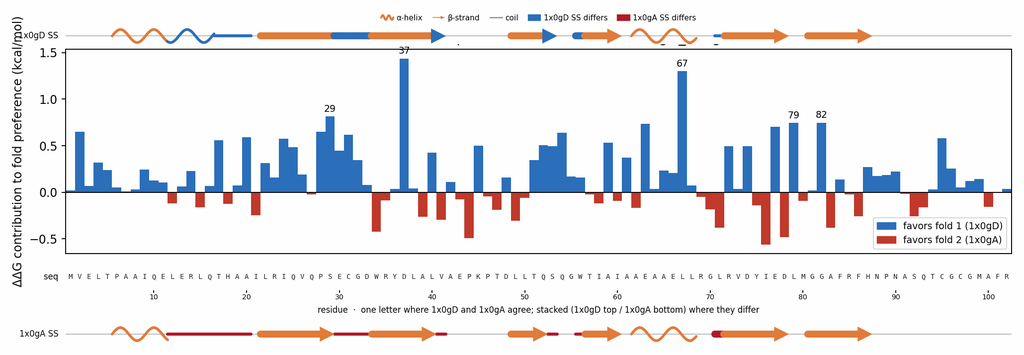

**More figures**

## Figure 6: Deep-MSA contact map panel / Best clusters contact map panel

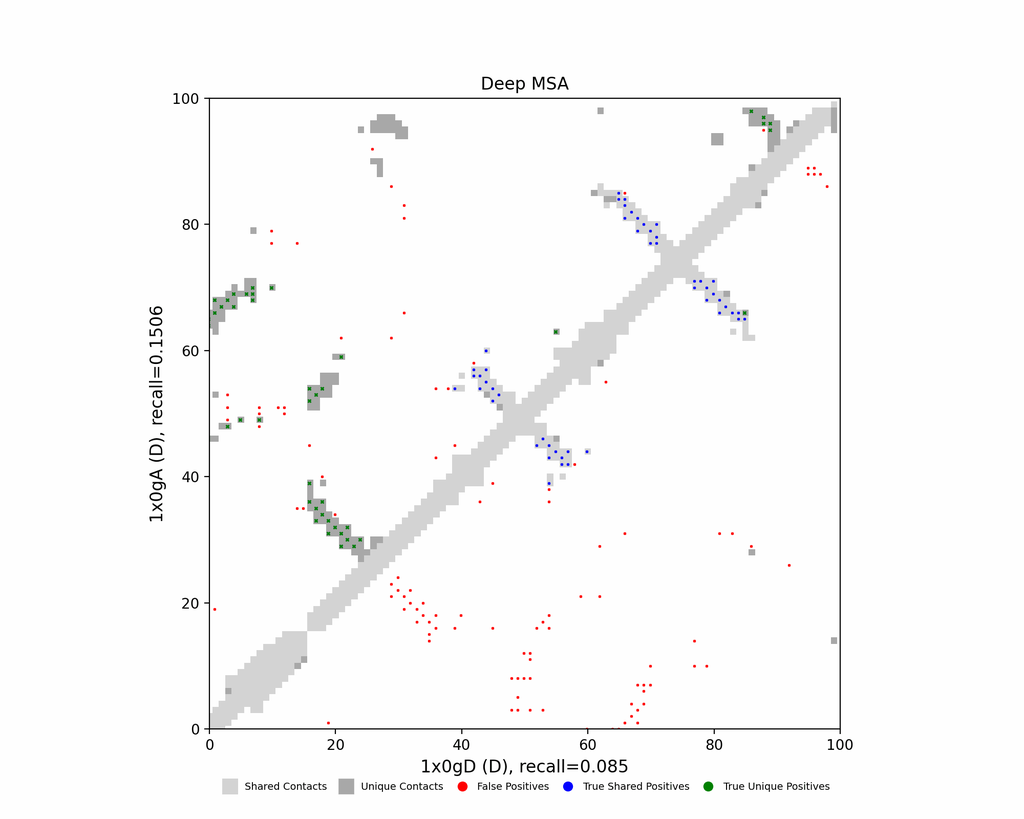

Deep-MSA contact map panel

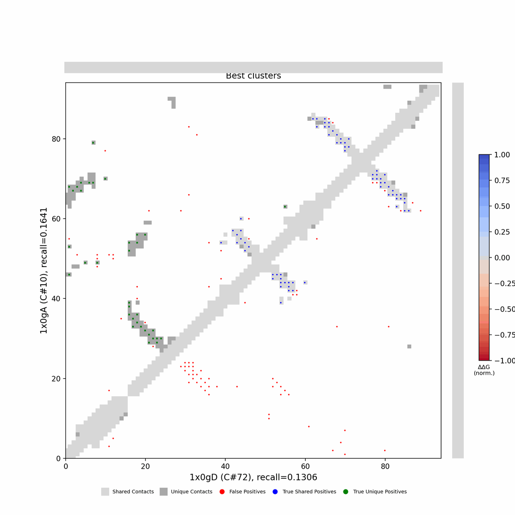

Best clusters contact map panel

## Figure 7: All clusters contact-map mosaic (small multiples).

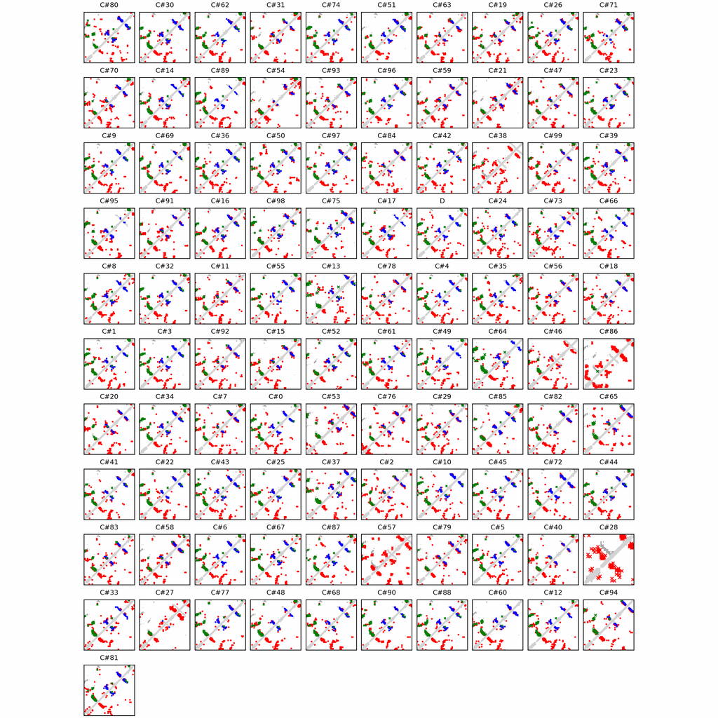

## Figure 8: Phylo null: tree with shuffled cluster fold labels.

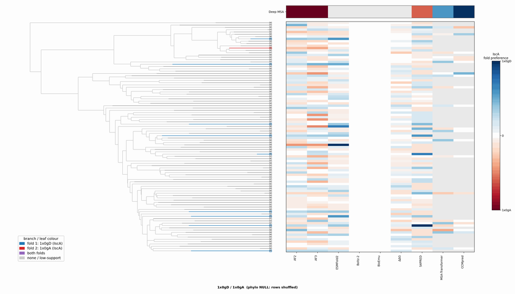

## Cluster metrics table

Per-cluster metrics underlying the figures above.

| cluster | n | neff | AF2_TM1 | AF2_TM2 | AF3_TM1 | AF3_TM2 | RE-MSAT-COM | RE-MSAT1 | RE-MSAT2 | ESM_SEQIDS | ESM_TM1 | ESM_TM2 | ΔΔG_Bias | ΔΔG_Bias_std | ΔΔG_frac_F1 | Boltz2_pref | S4PRED_pref | CCMpred_pref | BioEmu_pref |
| --- | --- | --- | --- | --- | --- | --- | --- | --- | --- | --- | --- | --- | --- | --- | --- | --- | --- | --- | --- |
| Deep | - | - | 0.57 | 0.91 | 0.57 | 0.91 | 0.32 | 0.32 | 0.49 | - | - | - | - | - | - | - | -0.04 | 0.04 | - |
| 000 | 2443.0 | 1643.0 | 0.51 | 0.72 | 0.56 | 0.79 | 0.32 | 0.32 | 0.48 | 001; 001; 002; 005; 005; 002; 008; 008; 009; 009 | 0.52 ± 0.03 | 0.79 ± 0.07 | 16.18 | 8.43 | 0.9 | -0.1 | -0.02 | 0.01 | -0.21 |
| 001 | 1839.0 | 1322.0 | 0.52 | 0.78 | 0.51 | 0.84 | 0.3 | 0.31 | 0.52 | 001; 001; 009; 009; 003; 008; 008; 003; 005; 005 | 0.52 ± 0.01 | 0.77 ± 0.08 | 17.82 | 7.4 | 1.0 | -0.06 | -0.04 | 0.02 | -0.23 |
| 002 | 1777.0 | 1209.0 | 0.49 | 0.73 | 0.55 | 0.69 | 0.16 | 0.15 | 0.27 | 008; 008; 009; 009; 004; 004; 001; 001; 002; 002 | 0.50 ± 0.02 | 0.75 ± 0.06 | 15.46 | 5.67 | 1.0 | -0.15 | -0.04 | 0.0 | -0.2 |
| 003 | 1260.0 | 894.0 | 0.5 | 0.71 | 0.55 | 0.77 | 0.35 | 0.36 | 0.52 | 001; 001; 009; 009; 004; 004; 003; 003; 005; 006 | 0.53 ± 0.03 | 0.82 ± 0.09 | 15.41 | 5.07 | 1.0 | -0.06 | -0.04 | -0.0 | -0.19 |
| 004 | 1054.0 | 803.0 | 0.49 | 0.7 | 0.53 | 0.81 | 0.32 | 0.34 | 0.5 | 001; 001; 005; 005; 004; 004; 006; 006; 009; 009 | 0.51 ± 0.02 | 0.78 ± 0.04 | 18.4 | 4.11 | 1.0 | -0.2 | -0.05 | 0.01 | -0.18 |
| 005 | 430.0 | 320.0 | 0.5 | 0.75 | 0.58 | 0.74 | 0.29 | 0.3 | 0.51 | 001; 001; 010; 010; 008; 008; 009; 009; 002; 002 | 0.53 ± 0.02 | 0.77 ± 0.08 | 17.2 | 5.78 | 1.0 | -0.03 | -0.01 | -0.01 | -0.2 |
| 006 | 391.0 | 277.0 | 0.51 | 0.75 | 0.48 | 0.66 | 0.34 | 0.34 | 0.46 | 001; 001; 003; 003; 008; 008; 004; 004; 009; 009 | 0.52 ± 0.03 | 0.76 ± 0.08 | 14.52 | 6.92 | 1.0 | -0.11 | -0.03 | 0.0 | -0.2 |
| 007 | 243.0 | 182.0 | 0.49 | 0.72 | 0.51 | 0.74 | 0.19 | 0.17 | 0.26 | 001; 002; 002; 001; 010; 010; 009; 009; 003; 003 | 0.52 ± 0.02 | 0.77 ± 0.06 | 16.27 | 3.77 | 1.0 | -0.08 | -0.04 | -0.0 | -0.15 |
| 008 | 190.0 | 78.0 | 0.35 | 0.39 | 0.38 | 0.54 | 0.26 | 0.24 | 0.24 | 008; 008; 005; 005; 003; 003; 004; 004; 001; 001 | 0.52 ± 0.02 | 0.77 ± 0.04 | 9.71 | 3.72 | 1.0 | -0.07 | -0.04 | 0.0 | -0.03 |
| 009 | 165.0 | 102.0 | 0.49 | 0.75 | 0.51 | 0.75 | 0.31 | 0.33 | 0.4 | 001; 001; 002; 002; 009; 007; 007; 009; 004; 004 | 0.50 ± 0.01 | 0.75 ± 0.06 | 13.26 | 5.12 | 1.0 | -0.05 | -0.01 | -0.0 | -0.22 |
| 010 | 154.0 | 118.0 | 0.45 | 0.6 | 0.51 | 0.69 | 0.38 | 0.39 | 0.53 | 001; 005; 005; 004; 001; 004; 002; 002; 003; 003 | 0.49 ± 0.02 | 0.74 ± 0.05 | 15.12 | 5.52 | 1.0 | -0.07 | -0.05 | 0.0 | -0.11 |
| 011 | 139.0 | 99.0 | 0.5 | 0.73 | 0.51 | 0.81 | 0.2 | 0.19 | 0.21 | 003; 003; 002; 002; 001; 009; 009; 007; 001; 007 | 0.51 ± 0.02 | 0.68 ± 0.05 | 14.72 | 5.9 | 1.0 | -0.14 | -0.04 | 0.0 | -0.16 |
| 012 | 137.0 | 101.0 | 0.46 | 0.6 | 0.49 | 0.71 | 0.24 | 0.23 | 0.31 | 001; 001; 005; 005; 003; 006; 006; 003; 004; 004 | 0.51 ± 0.01 | 0.79 ± 0.08 | 16.09 | 7.41 | 1.0 | -0.1 | -0.03 | -0.0 | -0.05 |
| 013 | 122.0 | 83.0 | 0.4 | 0.5 | 0.51 | 0.66 | 0.31 | 0.3 | 0.33 | 005; 005; 001; 001; 009; 009; 008; 008; 002; 002 | 0.51 ± 0.03 | 0.71 ± 0.02 | 17.08 | 2.57 | 1.0 | -0.04 | 0.03 | 0.0 | -0.1 |
| 014 | 112.0 | 61.0 | 0.51 | 0.72 | 0.38 | 0.44 | 0.22 | 0.23 | 0.26 | 006; 006; 001; 001; 005; 005; 002; 002; 003; 003 | 0.52 ± 0.03 | 0.73 ± 0.06 | 11.76 | 1.94 | 1.0 | -0.03 | -0.04 | 0.0 | -0.09 |
| 015 | 109.0 | 84.0 | 0.49 | 0.7 | 0.51 | 0.62 | 0.2 | 0.19 | 0.24 | 001; 001; 002; 002; 003; 003; 006; 004; 005; 004 | 0.52 ± 0.01 | 0.79 ± 0.06 | 15.45 | 6.96 | 1.0 | -0.05 | -0.01 | 0.0 | -0.14 |
| 016 | 101.0 | 79.0 | 0.45 | 0.59 | 0.53 | 0.83 | 0.33 | 0.33 | 0.39 | 003; 003; 005; 005; 001; 001; 007; 006; 006; 007 | 0.50 ± 0.02 | 0.76 ± 0.05 | 12.38 | 4.15 | 1.0 | -0.01 | -0.02 | 0.0 | -0.11 |
| 017 | 95.0 | 46.0 | 0.3 | 0.36 | 0.44 | 0.61 | 0.23 | 0.24 | 0.26 | 001; 001; 010; 010; 005; 006; 006; 005; 002; 002 | 0.53 ± 0.01 | 0.72 ± 0.03 | 10.04 | 4.35 | 0.9 | -0.02 | -0.04 | 0.0 | -0.05 |
| 018 | 88.0 | 65.0 | 0.38 | 0.5 | 0.39 | 0.48 | 0.16 | 0.14 | 0.24 | 004; 004; 003; 003; 001; 001; 005; 005; 009; 002 | 0.52 ± 0.02 | 0.79 ± 0.05 | 13.95 | 5.43 | 1.0 | -0.09 | -0.02 | 0.0 | -0.09 |
| 019 | 87.0 | 53.0 | 0.48 | 0.72 | 0.51 | 0.66 | 0.12 | 0.11 | 0.14 | 001; 001; 002; 002; 006; 003; 003; 006; 008; 008 | 0.53 ± 0.02 | 0.78 ± 0.04 | 12.93 | 3.95 | 1.0 | -0.07 | -0.03 | 0.0 | -0.09 |
| 020 | 85.0 | 57.0 | 0.49 | 0.64 | 0.49 | 0.61 | 0.17 | 0.15 | 0.15 | 001; 004; 004; 001; 005; 009; 003; 003; 005; 009 | 0.52 ± 0.00 | 0.84 ± 0.03 | 20.46 | 4.57 | 1.0 | -0.02 | -0.04 | 0.0 | -0.15 |
| 021 | 78.0 | 48.0 | 0.47 | 0.57 | 0.46 | 0.52 | 0.2 | 0.19 | 0.19 | - | - | - | 19.16 | 3.68 | 1.0 | -0.04 | -0.04 | - | -0.04 |
| 022 | 77.0 | 60.0 | 0.33 | 0.52 | 0.5 | 0.68 | 0.23 | 0.23 | 0.36 | - | - | - | 17.09 | 5.67 | 1.0 | -0.01 | -0.03 | - | -0.17 |
| 023 | 75.0 | 53.0 | 0.55 | 0.73 | 0.56 | 0.78 | 0.38 | 0.42 | 0.36 | - | - | - | 14.47 | 6.36 | 1.0 | -0.18 | -0.03 | - | -0.14 |
| 024 | 74.0 | 54.0 | 0.52 | 0.69 | 0.48 | 0.71 | 0.35 | 0.37 | 0.43 | - | - | - | 15.56 | 6.05 | 1.0 | -0.16 | -0.04 | - | -0.02 |
| 025 | 73.0 | 53.0 | 0.47 | 0.64 | 0.46 | 0.66 | 0.29 | 0.32 | 0.31 | - | - | - | 15.22 | 6.58 | 1.0 | -0.05 | -0.04 | - | -0.08 |
| 026 | 73.0 | 58.0 | 0.45 | 0.59 | 0.52 | 0.82 | 0.32 | 0.34 | 0.43 | - | - | - | 14.16 | 4.97 | 1.0 | -0.06 | -0.02 | - | -0.13 |
| 027 | 68.0 | 32.0 | 0.42 | 0.61 | 0.52 | 0.61 | 0.02 | 0.02 | 0.05 | - | - | - | 14.52 | 4.42 | 1.0 | -0.17 | -0.02 | - | -0.13 |
| 028 | 67.0 | 38.0 | 0.57 | 0.91 | 0.57 | 0.9 | 0.0 | 0.0 | 0.0 | - | - | - | 14.86 | 5.94 | 1.0 | -0.03 | -0.04 | - | -0.26 |

[output cut: 71 more lines]